# Stadium Event Date

## Summary

This notebook examines mobile data during the time of an event at a stadium and infers when an event is most likely to have occured.

### Input

pings_for_test.csv - cellular data

### Logic

- Reads in data
- Using max and min timestamp per device calculates time spent at the location.
- Average durations by date
- Plot average duration per date
- Calculate and plot unique visits per date
- Shiny heatmap with duration as intensity over the time period

#### Load packages

```r
suppressPackageStartupMessages({
  library(dplyr)
  library(ggplot2)
  library(lubridate)
  library(leaflet)
  library(leaflet.extras)
  library(shiny)
  library(shinyWidgets)
  library(shinyBS)
})
```

#### Read in ping data

```r
data = read.csv('/Users/alec/Data/stadium/pings_for_test.csv')
```

#### Calculate average timestamp duration with average lat and long for each device

```r
data_with_duration <- data %>%
  mutate(date = as.Date(date)) %>%
  group_by(id, date) %>%
  summarise(duration = max(unix_timestamp) - min(unix_timestamp),
            latitude = mean(latitude),
            longitude = mean(longitude))
```

#### Calculate average duration per date

| date | average_duration |
| --- | --- |
| 2023-05-01 | 3257.574 |
| 2023-05-02 | 4081.083 |
| 2023-05-03 | 3356.915 |
| 2023-05-04 | 4002.542 |
| 2023-05-05 | 3534.403 |
| 2023-05-06 | 10818.486 |
| 2023-05-07 | 2019.820 |
| 2023-05-08 | 1520.429 |
| 2023-05-09 | 5250.683 |
| 2023-05-10 | 2281.372 |

[output cut: 1 more lines]

#### Plot average duration per day

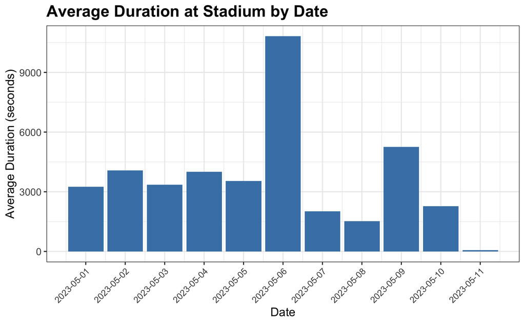

```r
ggplot(average_duration_by_date, aes(x = date, y = average_duration)) +
  geom_bar(stat = "identity", fill = "steelblue") +
  labs(title = "Average Duration at Stadium by Date",
       x = "Date",
       y = "Average Duration (seconds)") +
  theme_bw() +
  theme(plot.title = element_text(face = "bold", size = 16),
        axis.title = element_text(size = 12),
        axis.text.x = element_text(angle = 45, hjust = 1, vjust = 1),
        axis.text.y = element_text(size = 10)) +
  scale_x_date(date_breaks = "1 day", date_labels = "%Y-%m-%d")
```

```r
NA
NA
NA
```

#### Calculate visits per day

Based on this duration plot it seems like there was an increase in duration on the 6 May 2023.

Lets look at the number of visitors per day.

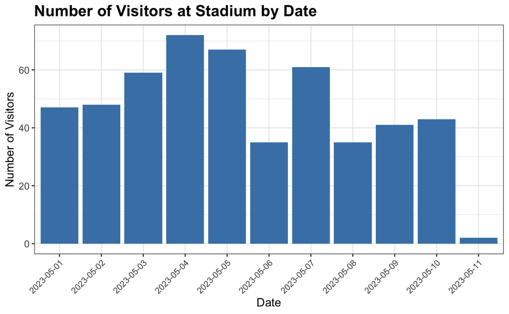

#### Create shiny heatmap showing changes over the dates intensity is the average duration per day.

Interestingly theres a drop in unique visitors on the 6th of May. This could indicate less people were passing through with a smaller number staying for the entire event.

Lets visualise where this is and create a heatmap

```r
suppressPackageStartupMessages({
  library(leaflet)
  library(leaflet.extras)
  library(shiny)
  library(shinyWidgets)
  library(shinyBS)
})

server <- function(input, output) {
  # Filter the data based on the selected date range
  filteredData <- reactive({
    data_with_duration %>%
      filter(date >= input$dateRange[1] & date <= input$dateRange[2])
  })

  # Calculate the minimum and maximum dates
  minDate <- min(data_with_duration$date)
  maxDate <- max(data_with_duration$date)

  # Create the leaflet map
  output$heatmapPlot <- renderLeaflet({
    leaflet() %>%
      addProviderTiles("Esri.WorldStreetMap") %>%
      setView(lng = -0.1266592, lat = 51.50461, zoom = 15) %>%
      addHeatmap(data = filteredData(),
                 lng = ~longitude, lat = ~latitude,
                 intensity = ~duration,
                 radius = 10, blur = 1,
                 max = max(data_with_duration$duration),
                 gradient = heat.colors(200))
  })

  # Create the date range slider
  output$dateSlider <- renderUI({
    sliderInput("dateRange", "Date Range",
                min = minDate, max = maxDate,
                value = c(minDate, maxDate),step = 1, width = "100%",
                timeFormat = "%Y-%m-%d")
  })
}

ui <- fluidPage(
  titlePanel("Stadium Event Date Heatmap"),
  mainPanel(
    leafletOutput("heatmapPlot", width = "100%", height = "500px"),
    br(),
    uiOutput("dateSlider")
  )
)

shinyApp(ui = ui, server = server)
```

[output not shown]

[output cut: 20 more lines]

```
NA
```

#### Conclusion

Based on the location near the Horse Guards Parade and given the date with the longest duration being the 6 May 2023 - it seems likely that the event was King Charles’s coronation.